# CMSC320 final project

Benjamin Drgon

5/17/2020

## Dataset

The dataset we will be looking at is a snapshot of the global rankings for the video game “Osu!”. Osu! is a rhythm game, similar to guitar hero, in which players compete for score on different maps. A map is an arrangement of circles set to the beat of a song, and played by clicking the circles to the beat. this dataset includes global leaderboard data for the top 100 players on March 26, 2017. Here is a breakdown of what some of the columns signifiy:

## play_count, level, hours, total_hits, ranked score

These columns are all roughly related to the amount of time a player has spent playing the game.

Play_count gives the total number of plays that player has subitted to the Osu! servers. This statistic can be innacurate because it doesn’t count plays that the player didn’t submite because they weren’t logged in.

level give the player’s account level, which goes higher as the player plays more. Past level 100, the time needed to achieve the next level goes up exponentially, so few of even the top ranked players have achieved more than 102.

hours may be the most directly useful playtime stat. It gives the amount of time the player has spent actively clicking circles. By comparing a player’s hours and play_count we can calculate the average length of the maps that player plays.

total_hits is yet another metric that give the total number of individual circles the player has clicked.

ranked_score gives the total of a player’s top scores on UNIQUE maps. This statistic is mostly useful as a measure of how many different maps a player has played.

Some other useful statistics are in the columns labelled accuracy, watched_by, and the counter attributes ss, s, and a

The accuracy column gives an overall measure of a player’s accuracy. It is calculated in a similar manner to performance_points, with a player’s highest rated play having the greatest impact on the value.

watched_by gives the number of time another player has watched a replay file of the given player playing. Can be used as a rough measure of a player’s notoriety or popularity.

ss, s, and a give the total number of unique maps on which the given player has achieved ranks of ss, s, or a. SS is the highest possible grade, and signifies perfect accuracy on that map, while S means imperfect timing with no misses. These columns will be relatively useless because they don’t account for map difficulty. Any of these players could inflate this number by playing a larger quantity of easier maps.

## Setup.

Start by reading ranking.csv, which contains our data set. Also load up useful libraries for later

# Plot accuracy against rank

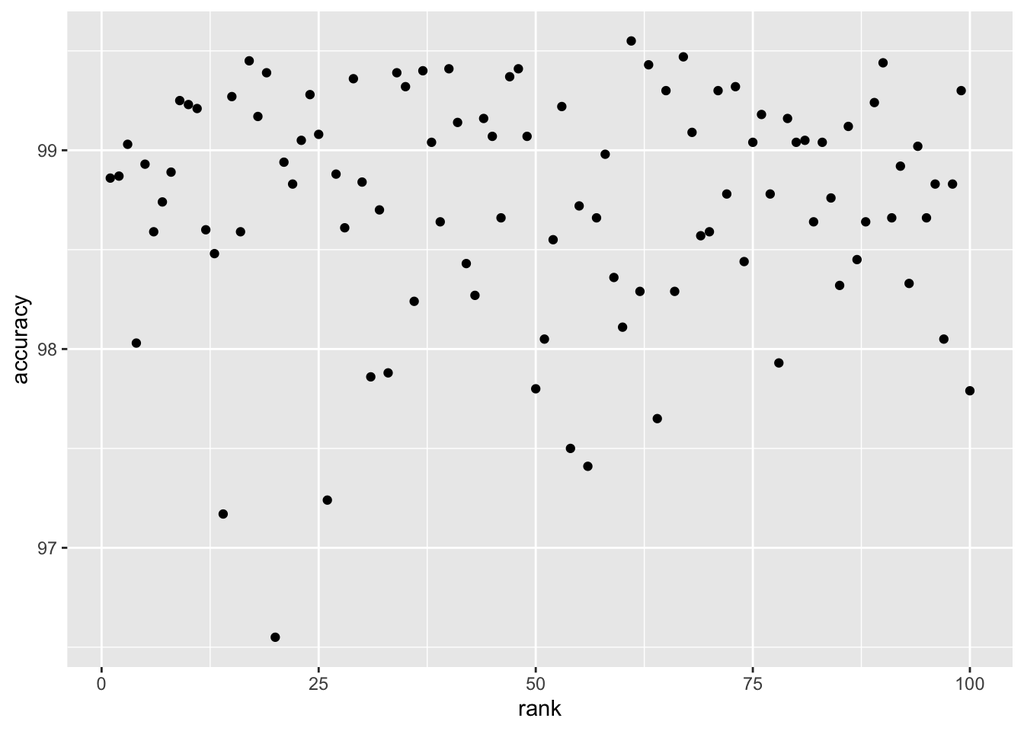

```r
ggplot(dat, aes(x=rank, y=accuracy)) + geom_point()
```

As you can see, there is not a visible correlation. This may be because we are only looking at the top 100 players. Based on my experience with the game this plot appears random because the different playstyles present in the top ranks.

## Pipeline

To start looking at this dataset, I will generate some new columns using data in the playtime-based metrics. Specifically, I will find the average_map_length by dividing total hours by play_count, and I will find an average circle rate by dividing total hits by hours. Finally, I generate average_hits_per_map by dividing total_hits by playcount. There three new columns will represent information about the types of maps a player tends to play. The previous plot shuggests a log transformation, which makes sense for an accuracy measure, which maxes out at 100%. A log of this metric may better represent a player’s distance from 100% accuracy

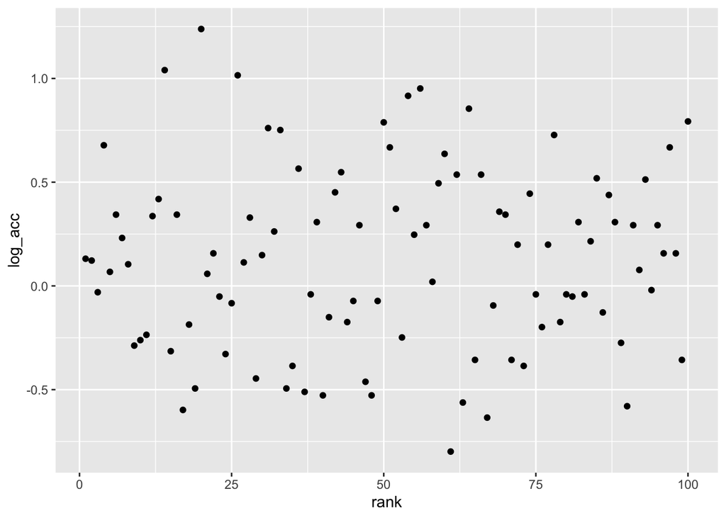

```r
dat <- mutate(dat, average_map_length = hours/play_count) %>%
  mutate(average_hit_rate = total_hits/hours) %>%
  mutate(average_map_hits = total_hits/play_count) %>%
  mutate(log_acc = log(100 - accuracy))
ggplot(dat, aes(x=rank, y=log_acc)) + geom_point()
```

log(100-accuracy) gives us a better spread, but plotting this against player rank is still useless. We will try plotting against some of the newly generated columns.

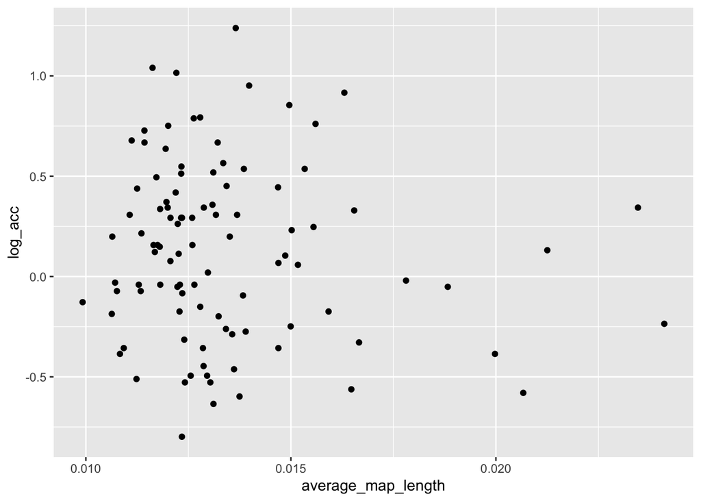

```r
ggplot(dat, aes(x=average_map_length, y=log_acc)) + geom_point()
```

This plot is interesting. Visibly, more player average shorter maps. While the most accurate player here plays shorter maps, the couple of long map players have above average accuracy. This follows the intuition that the consistency needed to get through longer maps allows these players to achieve a higher overall accuracy. Remember that log_acc = log(100 - accuracy), so points at 0 mean 99% accuracy.

## Visualization

For a couple more plots, we will visualize the relation between total playtime stats and rank. Use geom_smooth() to add a regression line. As you can see, adding a linear regression line shows that playing longer maps predicts achieving a higher rank.

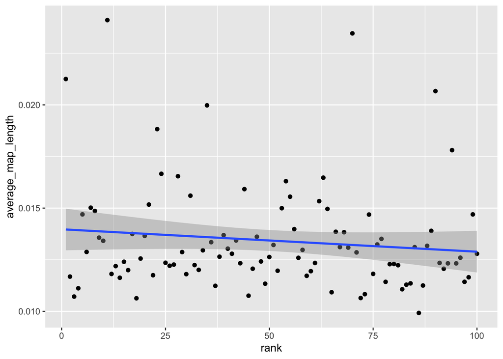

```r
ggplot(dat, aes(x=rank, y=average_map_length)) + geom_point() + geom_smooth(method="lm")
```

## Machine learning

Can we create a model to predict some player attribute given some other attributes? Let’s treat the player level as a categorical variable and see if it can be predicted using the playtime attributes of play_count or hours. Intuitively, this prediction should be possible because we know that players earn progress towards the next level by playing, so a higher playcount should predict a higher level. Specifically, we will try to predict level using hours and ranked score.

To do this we will be using a knn(k nearest neighbors) algorithm, which is part of the r class library. We loaded this library above with library(class). For more in depth information on how knn modeling works, check out this link: http://www.cs.cornell.edu/courses/cs4758/2013sp/materials/cs4758-knn-lectureslides.pdf

# knn model training on 90% of the set to predict the last 10%

```r
knn_100 <- function(size){
  #randomly sample 90% of rows
  rand <- sample(1:nrow(dat), size*nrow(dat))
  #create a norm function
  norm <- function(x) {(x-min(x))/(max(x)-min(x))}
  norm_dat <- as.data.frame(lapply(dat[, c(8, 10)], norm))
  #extract training set and testing set from normalized data
  dat_train = norm_dat[rand,]
  dat_test = norm_dat[-rand,]
  #get prediction target (level column) and test target
  target_dat <- as.factor(dat[rand,7])
  target_test <- as.factor(dat[-rand,7])
  #run knn function
  predict <- knn(dat_train, dat_test, cl=target_dat, k=10)
  #confusion matrix
  tbl <- table(predict, target_test)
  #accuracy function
  accuracy <- function(x){sum(diag(x)/(sum(rowSums(x)))) * 100}
  #call model accuracy function
  accuracy(tbl)
}
knn_100(0.9)
```

```
## [1] 80
```

# Refining the model

The above model gives a different accuracy each time it is run. This means that different subsets of the data are more useful in predicting new data, and the accuracy of the model depends mostly on whether the predicted players include any outliers. We adjust for this by sampling half of the dataset instaed of 90% for training. This way our model is checked against 50 entries instead of just 10 and outliers have less of a negative impact on accuracy

We encapsulated the model within a function, so we can run it by calling knn_100(x) where x is the proportion of the set to use as training data. Since we saw variation when running the model multiple times, we want to run the model several times and look for trends

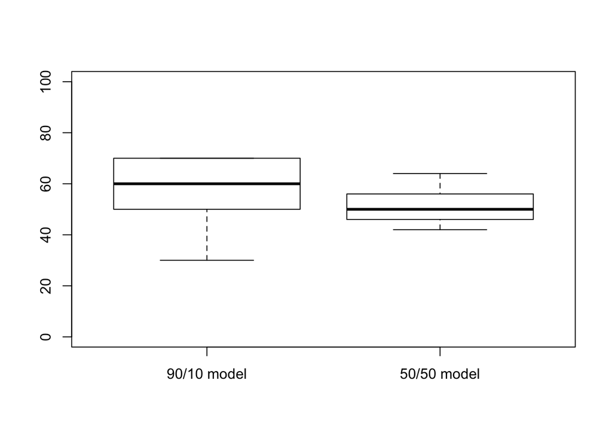

```r
#generate a vector of accuracies when running the knn model with 90% of the set as training data
accs90 = c()
for(x in 1:10){
  accs90 <- c(accs90, knn_100(0.9))
}

#now generate the same vector but training on 50% of the data
accs50 = c()
for(x in 1:10){
  accs50 = c(accs50, knn_100(0.5))
}

#display of boxplot of the distributions of accuracy for these two models
boxplot(accs90, accs50, names=c("90/10 model", "50/50 model"), ylim = c(0, 100))
```

While this 50% model also varies with each run, the accuracy varies much less.The boxplot above shows that training the model on 90% of the dataset and checking accuracy with 10% outputs an accuracy value with a much higher standard deviation than training on 50% and checking with 50%. This makes intuitive sense because the factorized player level has 4 possible values in this set, a truly random predictor would be expected to have an accuracy of 25%. This model consistently outperforms 25%.